# Intra- and interspecific variation in Swiss ants

## Distributional Model

### Overview

To assess the change in ant worker traits across the environmental gradient, we used a distributional model that simultaneously estimates the mean and standard deviation of worker traits within each colony. In brief, we assume worker traits are distributed normally within each colony, and that the mean and standard deviation of each colony may be dependent on the environment. We focus on non-polymorphic species where such an assumption is broadly reasonable. Species is treated as a random effect for both intercept and slope, such that each species can respond differently to the environment, but with the estimation of global effects and the ability for hierarchical pooling across taxa.

### Model structure

The trait value for each worker $i$ is distributed normally within each colony $j$ for each species $s$ such that:

$$\begin{equation}
y_{i,j,s} \sim Norm(\bar{y}_{j,s}, d_{j,s})
\end{equation}$$

where $\bar{y}_{j,s}$ is the intra-colony mean, and $d_{j,s}$ is the intra-colony standard deviation. Each intra-colony mean is therefore distributed about predicted value $\mu_{j,s}$ based on the environmental conditions such that:

$$\begin{equation}
\bar{y}_{j,s} \sim Normal(\mu_{j,s}, \sigma_{1})
\end{equation}$$

$$\begin{equation}
\mu_{j,s} = X_j b_s
\end{equation}$$

where $\sigma_{1}$ is the standard deviation, $X$ is a matrix of environmental covariates, and $b$ is a vector of species specific slopes.

Similarly, the within-colony variation is expected to be a function of the environment. Thus, the standard deviation within each colony $d_{j,s}$ is:

$$\begin{equation}
log(d_{j,s}) \sim Normal(\delta_{j,s}, \sigma_{2})
\end{equation}$$

$$\begin{equation}
\delta_{j,s} = V_j a_s
\end{equation}$$

where $\sigma_{2}$ is the standard deviation, $V$ is a matrix of environmental covariates, and $a_s$ is a vector of species specific slopes.

Thus, we assume that the both the intra-colony means and standard deviations may vary with environmental conditions. The hierarchical priors on $b$ and $a$ allow for taxonomic clustering among genera:

$$\begin{equation}
b_{p,s} \sim Norm(B_{p,g}, \sigma_{b_p})
\end{equation}$$
$$\begin{equation}
B_{g} \sim mvNorm(\beta, \Sigma_B)
\end{equation}$$

$$\begin{equation}
a_{p,s} \sim Norm(A_{p,g}, \sigma_{a_p})
\end{equation}$$
$$\begin{equation}
A_{g} \sim mvNorm(\alpha, \Sigma_A)
\end{equation}$$

where $B_{g}$ and $A_{g}$ are genus-level averages with standard deviations $\sigma_{b_p}$ and $\sigma_{A_p}$ for each variable $p$, and $\beta$ and $\alpha$ are overall average responses among all species with covariance matrices $\Sigma_B$ and $\Sigma_A$.

## Traits

Table 1. Ant traits included in the analyses.

| Trait | Abbr. | Description | Relevance | Expected Env. Patterns | Type | Sources |
| --- | --- | --- | --- | --- | --- | --- |
| Weber’s Length | WL | Pronotum anterior to propodeum posterior | Overall body size, linked to resource use | $$\begin{align*} \mu: +Temp -AP \\ \sigma: -Temp -AP \end{align*}$$ | Absolute | Bernstein 1976, Cerda & Retana 1997, Kaspari & Weiser 1999, Bishop et al 2016, Gibb et al 2018 |
| Head Length | HL | Top of head to margin of clypeus along center line | Overall body size, linked to predatory strategy | $$\begin{align*} \mu: +Temp -AP \\ \sigma: -Temp -AP \end{align*}$$ | Absolute | Bernstein 1976, Cerda & Retana 1997, Kaspari & Weiser 1999, Silva & Brandão 2010, Bishop et al 2016, Gibb et al 2018 |
| Head Width | HW | Maximum width above eyes | Overall body size, linked to predatory strategy | $$\begin{align*} \mu: +Temp -AP \\ \sigma: -Temp -AP \end{align*}$$ | Absolute | Kaspari 1993, Sarty et al 2006, Schofield et al 2016, Bernadou et al 2016 |
| Color (brightness) | V | Median V in HSV color of mesosoma dorsum | Thermal regulation, protection from UV-B | $$\begin{align*} \mu: +Temp -AP \\ \sigma: -Temp -AP \end{align*}$$ | Absolute | Bernstein 1976, Willmer & Unwin 1981, Cerda & Retana 1997, Bishop et al 2016 |
| Head Shape | HS | HW / HL | Foraging and stuff | $$\begin{align*} \mu: ? \\ \sigma: ? \end{align*}$$ | Relative | Sosiak & Barden 2021 |
| Leg Length | LL | (Hind Femur + Tibia) / WL | Walking speed, foraging spaces available | $$\begin{align*} \mu: -Temp \\ \sigma: +NPP \end{align*}$$ | Relative | Sarty et al 2006, Silva & Brandão 2010, Gibb & Parr 2010, 2013 |
| Scape Proportion | SP | Scape Length / HL | Foraging and stuff | $$\begin{align*} \mu: -Temp \\ \sigma: ? \end{align*}$$ | Relative | Silva & Brandão 2010, Sosiak & Barden 2021 |
| Pronotal Expansion | PE | Pronotum Width / WL | Foraging and stuff | $$\begin{align*} \mu: ? \\ \sigma: ? \end{align*}$$ | Relative | Gibb & Parr 2013, Keller et al 2014, Sosiak & Barden 2021 |
| Interocular distance | IO | Interocular distance / HW | Foraging strategy | $$\begin{align*} \mu: -Temp \\ \sigma: ? \end{align*}$$ | Relative | FOR DVE: Weiser & Kaspari 2006, Narendra et al 2013, Sosiak & Barden 2021 |

# Results

See the [trait distributions](https://sz-tim.github.io/CH_traits/trait_distributions.html#Variance-partitioning) notebook for more variance partitioning and exploration of the distribution and variance of traits.

# References

Sosiak & Barden (2021) also report that relative (scaled) traits are less variable across ecomorphs (section 3.1).

# Scratch

## Within-colony variation

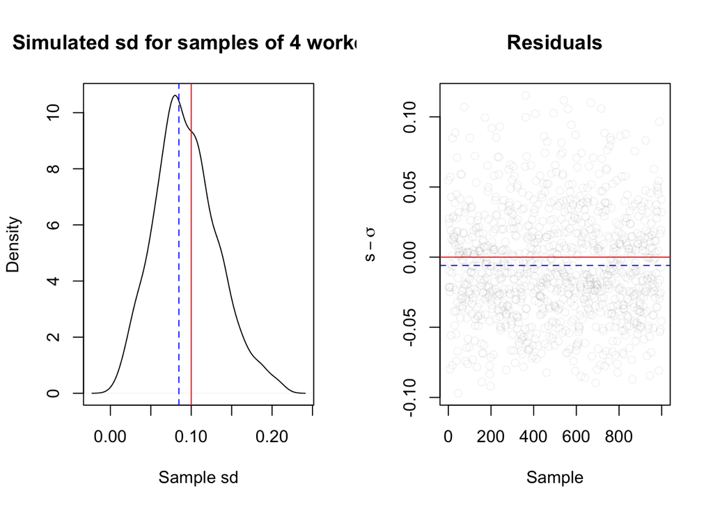

```r
sd_true <- 0.1
wkr_samples <- map_dbl(1:1e3, ~sd(rnorm(4, 0, sd_true)))

par(mfrow=c(1,2))
plot(density(wkr_samples), main="Simulated sd for samples of 4 workers",
     xlab="Sample sd")
abline(v=sd_true, col="red")
abline(v=exp(mean(log(wkr_samples))), col="blue", lty=2)

plot((wkr_samples - sd_true), main="Residuals", col=rgb(0,0,0,0.05),
     xlab="Sample", ylab=expression(s-sigma))
abline(h=0, col="red")
abline(h=mean(wkr_samples - sd_true), col="blue", lty=2)
```

```r
# Proportion of samples underestimating true sd
round(sum(wkr_samples < sd_true)/length(wkr_samples), 3)
```

```
## [1] 0.582
```

Thus, we should expect that, on average, the latent predicted within-colony standard deviation $d$ is larger than the standard deviation of the four measurements. More specifically, it should be something like 60% that underestimate it. This is a function of the sample size, rather than the standard deviation, at least assuming that the observations are, in fact, drawn from a normal distribution.

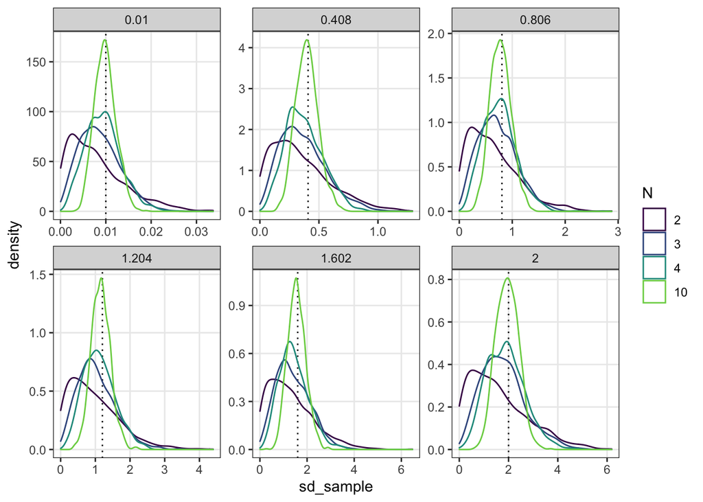

```r
sim.df <- expand.grid(N=c(2,3,4,10),
                      sd_true=seq(0.01, 2, length.out=6),
                      sim=1:1e3) %>%
  pmap_dfr(., function(N, sd_true, sim) tibble(N=N,
                                               sd_true=sd_true,
                                               sd_sample=sd(rnorm(N, 0, sd_true)))) %>%
  mutate(N=as.factor(N))
ggplot(sim.df, aes(sd_sample, colour=N)) +
  geom_vline(data=summarise(group_by(sim.df, N, sd_true),
                            N=first(N), sd_true=first(sd_true)),
             aes(xintercept=sd_true), lty=3) +
  geom_density() +
  scale_colour_viridis_d(end=0.8) + facet_wrap(~sd_true, scales="free")
```

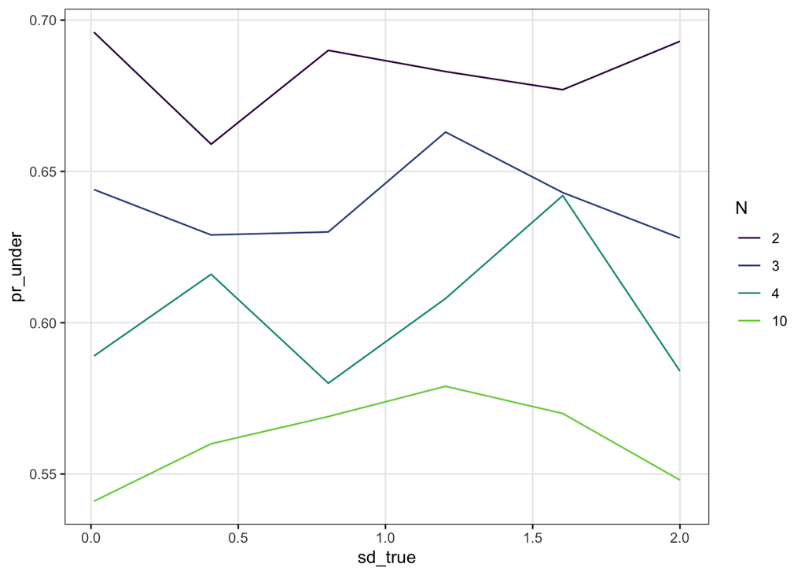

```r
# Proportion of samples underestimating true sd
sim.df %>% group_by(N, sd_true) %>%
  summarise(pr_under=sum(sd_sample < sd_true)/n()) %>%
  ggplot(aes(sd_true, pr_under, colour=N)) + geom_line() +
  scale_colour_viridis_d(end=0.8)
```

## Prediction notes

Given the assemblage-level work using species-level averages, there’s also the question of whether individual workers (or colonies) that are darker tend to be larger, and whether this corresponds with workers (or colonies) from colder environments. There is also a question of timing, where the size or color of workers could change with either the age of the individual worker (light just after eclosion, and possibly also fading with age?) or the date of eclosion (larvae developing at different points in the summer, fed different diets, experiencing different temperatures). For predictions based on date or season, I think I need to do more research.

Combining everything, the predictions *could* be:

1. In **cold** environments:
   1. Size
      - colony means are larger
      - q05 is larger, q95 is unchanged (?)
      - colony sd is larger (but conflicts with previous)
   2. Color
      - colony means are darker
      - colony sd is larger
   3. Relative Leg Length
      - colony means are smaller
   4. Relative Scape Length
      - colony means are smaller
2. In **wet** environments:
   1. Size
      - colony means are smaller
      - q05 is unchanged, q95 is smaller (?)
   2. Color
      - colony means are darker
3. In **early** season:
   1. Size
   2. Color
      - colony sd is larger at end of season (?)
4. In **highly variable** environments:
   1. Size
      - colony sd is larger
   2. Color
      - colony sd is larger
5. Size and color:
   1. Larger workers are darker
   2. Colonies with larger means have darker means
6. Predictions based on foraging habits?
   1. Species/genera that forage in open are more exposed
   2. Species in forests are less exposed
   3. Variation has larger impact for larger taxa?
      - a 10% change in size is physiologically more consequential for larger sizes